## **Input SNP-Level Summary Data**

Completed on: Thu Apr 06 21:32:36 2023 (Asia/Shanghai), with the runtime of (51 seconds).

> **An interactive table** for user-input SNPs (n=216, being processed). This table has three columns: 1st column `SNPs` for dbSNP rsIDs (hyperlinked to `dbSNP`), 2nd column `P-values` for use-input significance information, and 3rd column `Locus` for genomic locations (the genome build `hg19`).

| SNPs | Pvalue | Locus |
| --- | --- | --- |
| &nbsp;rs80174646 | 1e-143 | chr1:67708155-67708155 |
| &nbsp;rs7517847 | 1e-98 | chr1:67681669-67681669 |
| &nbsp;rs2066845 | 6e-94 | chr16:50756540-50756540 |
| &nbsp;rs1992661 | 1e-74 | chr5:40414989-40414989 |
| &nbsp;rs6426833 | 7e-62 | chr1:20171860-20171860 |
| &nbsp;rs17622378 | 2e-55 | chr5:131778452-131778452 |
| &nbsp;rs3197999 | 7e-55 | chr3:49721532-49721532 |
| &nbsp;rs9977672 | 5e-54 | chr21:40463283-40463283 |
| &nbsp;rs469758 | 6e-54 | chr5:96121715-96121715 |
| &nbsp;rs4672505 | 2e-52 | chr2:62560332-62560332 |

[output cut: 206 more lines]

## **Output: Linked Genes**

> **Linked Gene table** contains information on genes (n=407, linked from the input SNPs), including the column `GScores` (ranged from 1 to 10) that quantifies the degree to which genes are responsible for genetic associations. `Linked genes` are sorted by their linked gene scores and are hyperlinked to [GeneCards](https://www.genecards.org) for further information. Please refer to **`Evidence table`** for details on the linking evidence.

| Linked genes | GScores | Description |
| --- | --- | --- |
| IL23R | 10 | interleukin 23 receptor |
| RNU6-586P | 9.163 | RNA, U6 small nuclear 586, pseudogene |
| CYLD | 8.733 | CYLD lysine 63 deubiquitinase |
| NOD2 | 8.733 | nucleotide binding oligomerization domain containing 2 |
| IRF1 | 5.265 | interferon regulatory factor 1 |
| IRF1-AS1 | 5.265 | IRF1 antisense RNA 1 |
| APEH | 5.217 | acylaminoacyl-peptide hydrolase |
| BSN | 5.217 | bassoon presynaptic cytomatrix protein |
| MST1 | 5.217 | macrophage stimulating 1 |
| RNF123 | 5.217 | ring finger protein 123 |

[output cut: 397 more lines]

> **Evidence table** displays information on which SNPs (see the column `SNPs`) are used to define linked genes (the column `Linked genes`) based on which evidence (see the column `Evidence`). The column `SNP type` indicates whether the SNP is an input SNP (`Input`) or an additional SNP in linkage disequilibrium (`LD`). The column `Evidence` contains information on the datasets used, such as `Proximity` (indicative of SNPs in proximity), the prefix `PCHiC_` (promoter capture Hi-C datasets), and the prefix `eQTL_` or `pQTL_` (e/pQTL datasets).

| SNPs | SNP type | Linked genes | Evidence |
| --- | --- | --- | --- |
| rs1004820 | LD | IL23R | Proximity_20000bp |
| rs10789230 | LD | IL23R | Proximity_20000bp |
| rs10889673 | LD | IL23R | Proximity_20000bp |
| rs10889677 | LD | IL23R | Proximity_20000bp |
| rs111379368 | LD | IL23R | Proximity_20000bp |
| rs11209026 | LD | IL23R | Proximity_20000bp |
| rs112106127 | LD | IL23R | Proximity_20000bp |
| rs113120270 | LD | IL23R | Proximity_20000bp |
| rs113155999 | LD | IL23R | Proximity_20000bp |
| rs113935720 | LD | IL23R | Proximity_20000bp |

[output cut: 5964 more lines]

## **Output: Gene Subnetwork**

> **A network visualisation** of the subnetwork, with 31 genes/nodes color-coded by linked gene scores (ranged from 1 to 10). An editable pdf file is also available for download.

DOWNLOAD .pdf

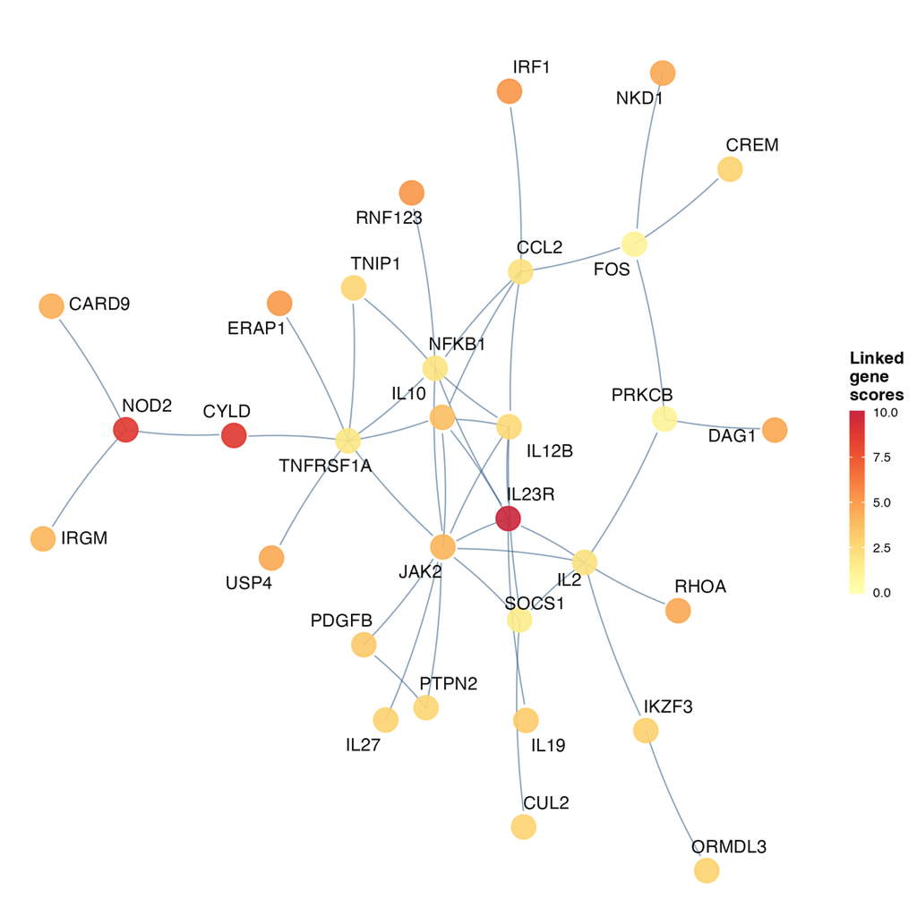

Figure 1: Visualisation of the identified subnetwork, with genes/nodes color-coded by linked gene scores (ranged from 1 to 10).

> **An interactive table** for the subnetwork genes (n=31), with the column `GScores` for linked gene scores (ranged from 1 to 10). Each gene listed in the column `Linked genes` is hyperlinked to its corresponding [GeneCards](https://www.genecards.org) page.

| Linked genes | GScores | Description |
| --- | --- | --- |
| IL23R | 10 | interleukin 23 receptor |
| NOD2 | 8.733 | nucleotide binding oligomerization domain containing 2 |
| CYLD | 8.733 | CYLD lysine 63 deubiquitinase |
| IRF1 | 5.265 | interferon regulatory factor 1 |
| RNF123 | 5.217 | ring finger protein 123 |
| ERAP1 | 5.133 | endoplasmic reticulum aminopeptidase 1 |
| DAG1 | 4.647 | dystroglycan 1 |
| NKD1 | 4.608 | NKD inhibitor of WNT signaling pathway 1 |
| USP4 | 4.589 | ubiquitin specific peptidase 4 |
| RHOA | 4.589 | ras homolog family member A |

[output cut: 21 more lines]